# Coursework assignment A - 2021

## Part 1 - Design and set-up of true experiment

## The motivation for the planned research

- Coronavirus
- Technology enabled transition
- Effect of online education on understanding

## The theory underlying the research

- Figlio et al. (2013): modest difference in exam scores in favour of the students only attending live lectures
- Nguyen (2015): 92% of papers find online education to be at least as effective as live education
- Finnegan (2021): results are marginally worse after the shift to online teaching

## Research questions

- “How is students’ understanding of lecture material affected by attending the lecture live rather than online?”

## The related conceptual model

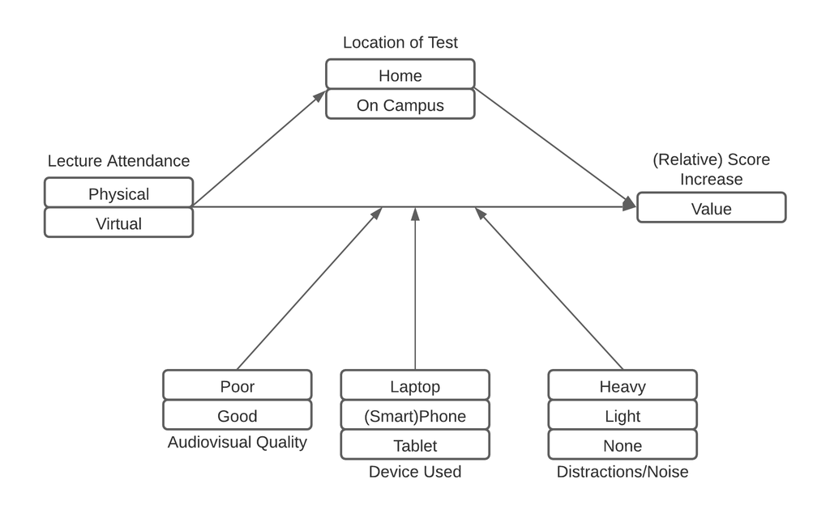

Conceptual Model underlying this research question

## Experimental Design

- Pre-test Post-test randomized controlled trial
- Participants divided randomly over live and online groups

## Experimental procedure

- One day each between pre-test, lecture, and post-test
- Pre-test and post-test consist of questions composed by the teacher giving the lecture
- Questions should reflect the main learning goals of the lecture
- Randomized block design based on pre-test scores
- Students in both conditions follow the same lecture at the same time

## Measures

- Pre-test as baseline measurement
- Score is proportion of correct answers
- Evaluate score\(_\text{post-test}\) / score\(_\text{pre-test}\)

## Participants

- Students recruited by asking for volunteers across a university campus
- Compensation offered

## Suggested statistical analyses

- \(H_0\): no difference in student understanding of the lecture material between the two different conditions.
- \(H_1\): difference in student understanding
- \(m_0\): intercept only
- \(m_1\): uses condition as predictor
- ANOVA F-test

## Part 2 - Generalized linear models

## Question 1 Twitter sentiment analysis (Between groups - single factor)

- Is there a difference in sentiment between the tweets about Justin Bieber, Taylor Swift and Billie Eilish?

### Conceptual model

- Celebrity is the main effect
- No additional data

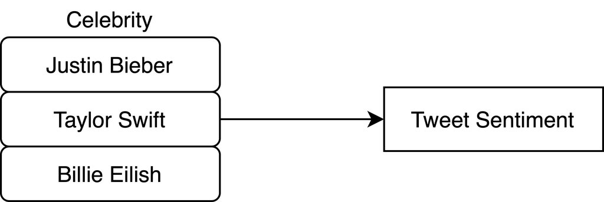

### Homogeneity of variance analysis

#### Boxplot

- Tweets about Billie Eilish most negative
- Justin Bieber’s and Taylor Swift’s are similar
- Justin Bieber’s bit more spread

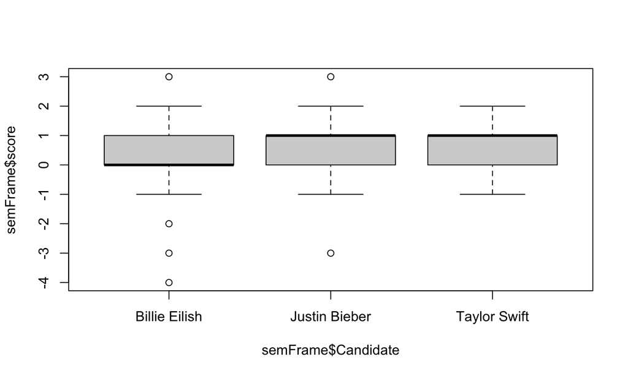

#### Levene Test

- Levene test to test for Homogeneity of Variance
- No Homogeneity of Variance (p < 0.01)
- Population variances are not equal

Levene’s Test for Homogeneity of Variance (center = median)

|  | Df | F value | Pr(>F) |
| --- | --- | --- | --- |
| **group** | 2 | 6.79 | 0.001183 |
|  | 897 | NA | NA |

### Visual inspection mean and distribution sentiments

- Tweets about Billie Eilish most neutral
- Tweets about Justin Bieber more positive than Taylor Swift

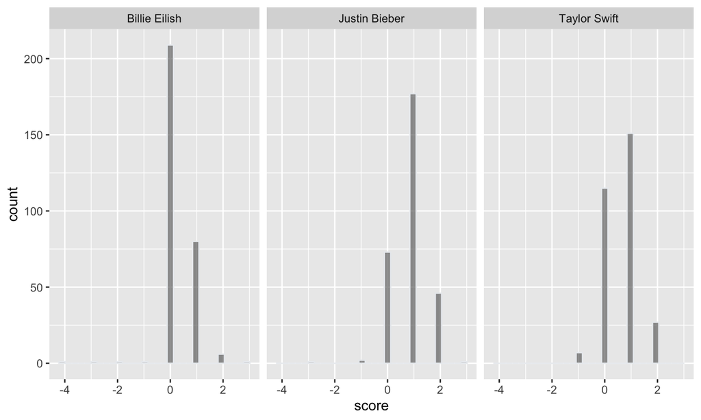

### Frequentist approach

- Create linear model using aov
  - Is there a difference in means?
- Post-Hoc Analyis (TukeyHSD)
  - Where lie the differences?

#### Linear model

- Difference in means?
- Pr(>F) < 0.01 -> Yes!

Analysis of Variance Model

|  | Df | Sum Sq | Mean Sq | F value | Pr(>F) |
| --- | --- | --- | --- | --- | --- |
| **Candidate** | 2 | 56.28 | 28.14 | 63.49 | 1.633e-26 |
| **Residuals** | 897 | 397.6 | 0.4433 | NA | NA |

#### Post Hoc analysis

- Further analysis…
- Do the celebrities differ from each other?
- Significant (p < 0.01) difference in means for all celebrity pairs

```
##   Tukey multiple comparisons of means
##     95% family-wise confidence level
##
## Fit: aov(formula = score ~ Candidate, data = semFrame, na.action = na.exclude)
##
## $Candidate
##                                   diff        lwr        upr    p adj
## Justin Bieber-Billie Eilish  0.6066667  0.4790493  0.7342841 0.00e+00
## Taylor Swift-Billie Eilish   0.3766667  0.2490493  0.5042841 0.00e+00
## Taylor Swift-Justin Bieber  -0.2300000 -0.3576174 -0.1023826 7.61e-05
```

#### Report section for a scientific publication

In order to determine whether sentiment of tweets depend on the celebrity they are about, a null model and a model with celebrity added as a independent variable predictor have been constructed. Results showed that the fit was significantly better (\(F(2, 897) = 63.49\), p. < 0.01) with the added predictor. We can therefore conclude that the Twitter user base tweets differently depending on the three celebrities in the data set. Further analysis using Post Hoc analysis using Tukey’s Honest Significant Difference test showed that there is a significant difference in tweet sentiment distribution in all three celebrity pairs, Taylor Swift - Justin Bieber (p. < 0.01), and Billie Eilish - Justin Bieber (p. < 0.01), and Taylor Swift - Billie Eilish (p. < 0.01).

### Bayesian Approach

- Same questions as frequentist
- Define priors
- Create Bayesian models
- T-test to compare celebrity pairs

#### Model description

- Sentiment values between -5 and 5
- Mean about 1

\[ \begin{aligned} \mu_{\text{celebrity}} & = N(a_{\text{celebrity}}, \sigma) \\ a & \sim N(1, 2) \\ \sigma & \sim U(0.0001, 5) \end{aligned} \]

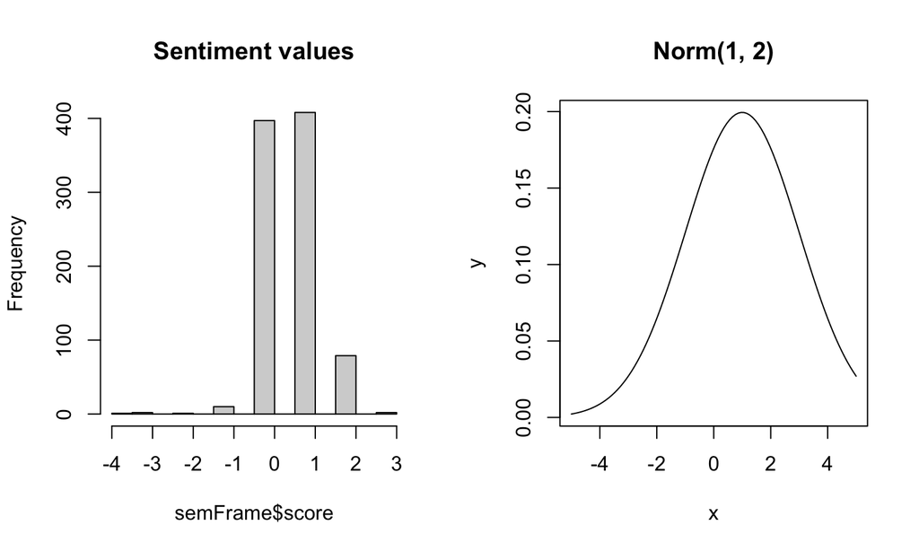

#### Creating the model

- Two models
  - Base model
  - Model with celebrity as predictor
- Parameters for second model:

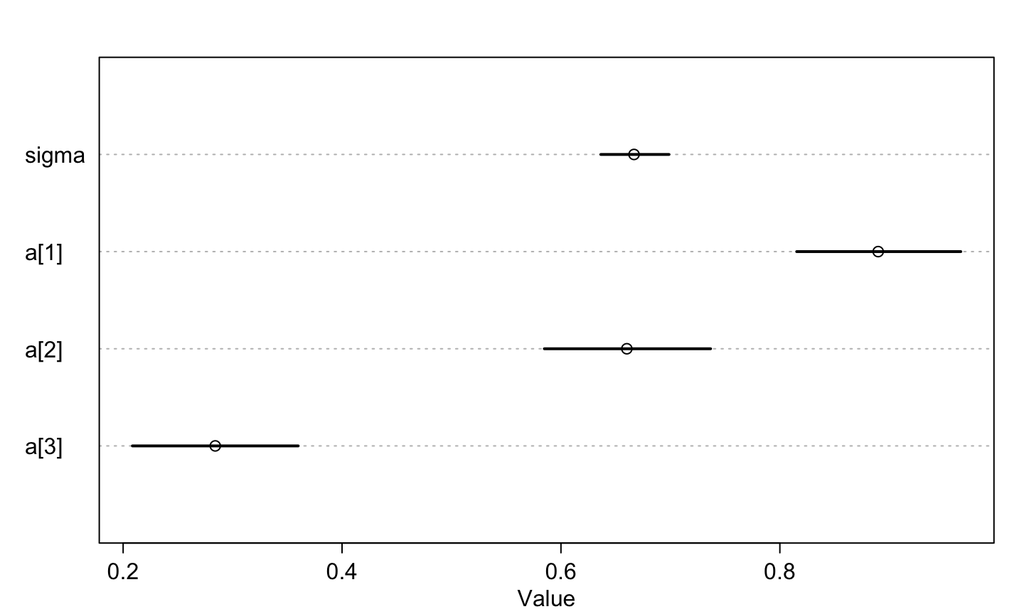

***

#### Comparing the fit

- Second model has lower WAIC
- -> Second model has better fit

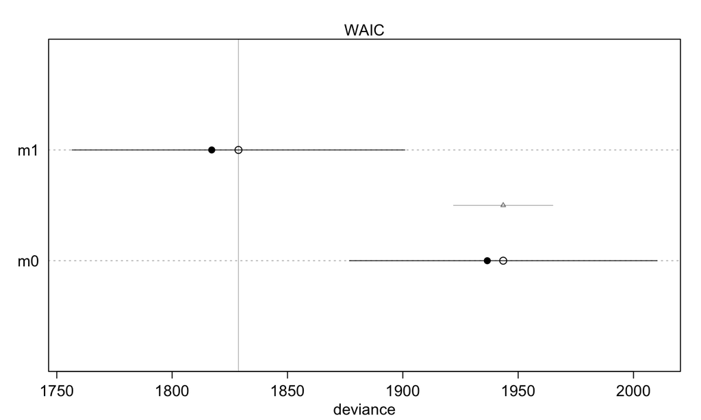

Comparison of the WAIC score for each model.

#### Comparison celebrity pair

- We know celebrity is main effect
- How do celebrities differ between each other?
- Bayes.t.test

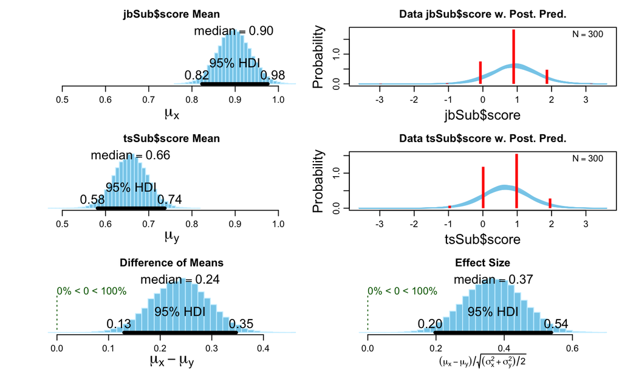

Results of performing the bayes t-test on the pair Justin Bieber - Taylor Swift.

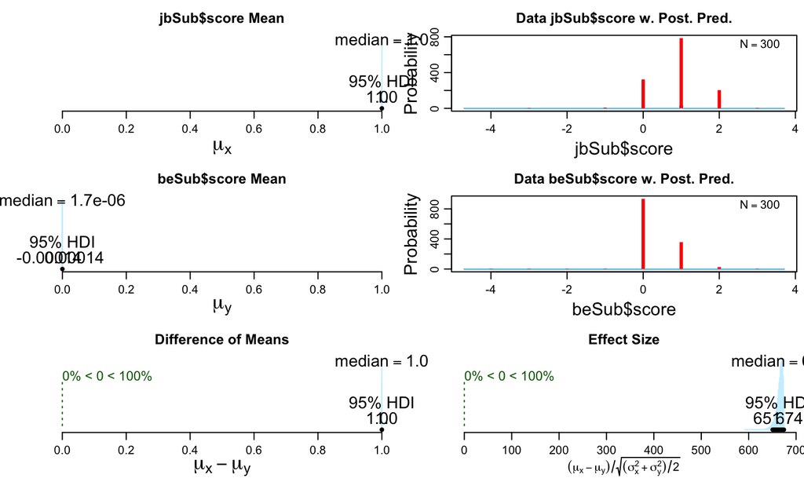

Results of performing the bayes t-test on the pair Justin Bieber - Billie Eilish.

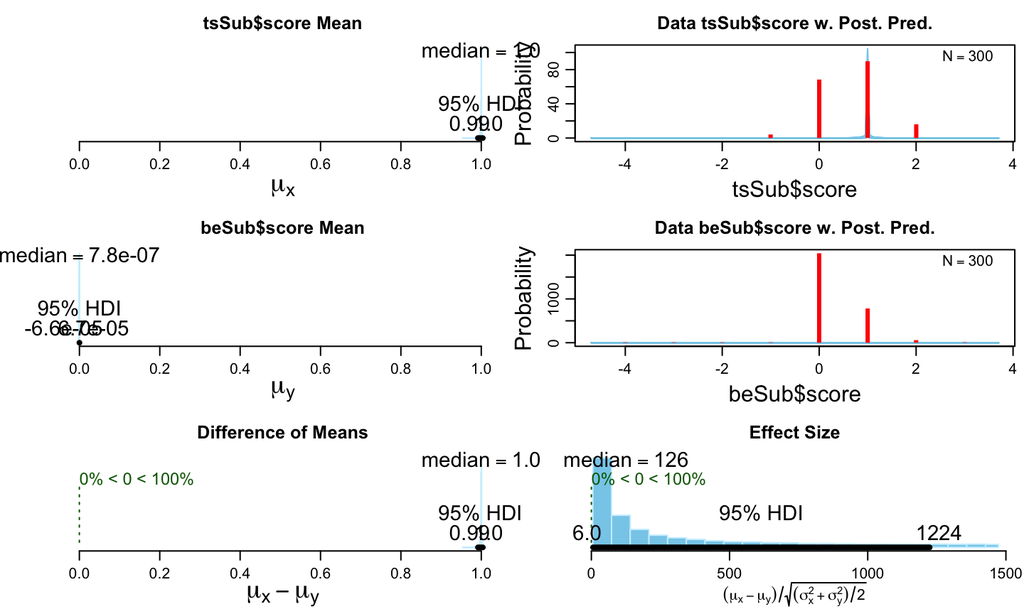

Results of performing the bayes t-test on the pair Taylor Swift - Billie Eilish.

#### Conclusions Celebrity Pair Comparison

- Significant difference (p < 0.01)

## Question 2 - Website visits (between groups - Two factors)

### Conceptual model

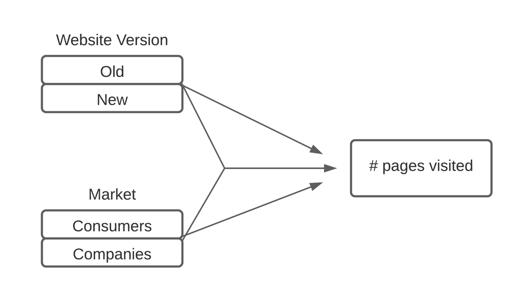

Conceptual Model underlying this research question

### Visual inspection - 1

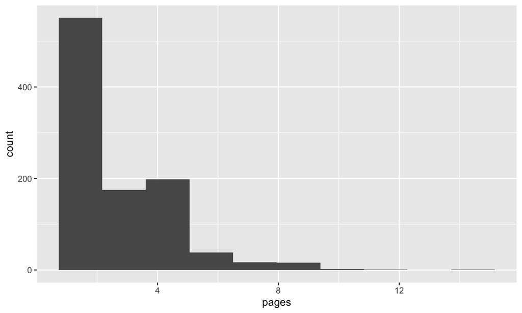

Histogram showing page visits on the website over all factors.

### Visual inspection - 2

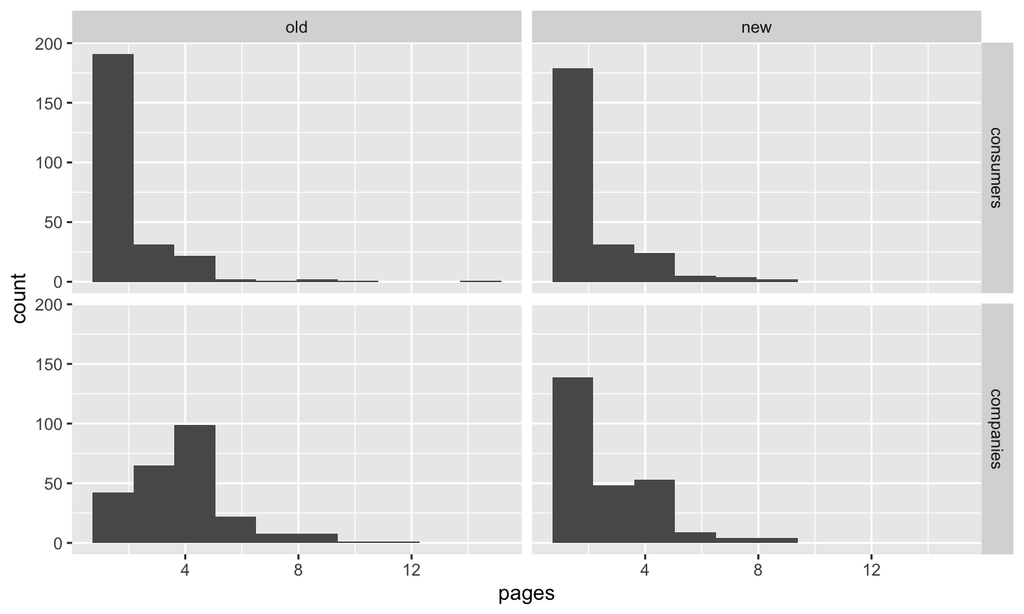

Histograms of page visits on the website per independent variable.

### Visual inspection - 3

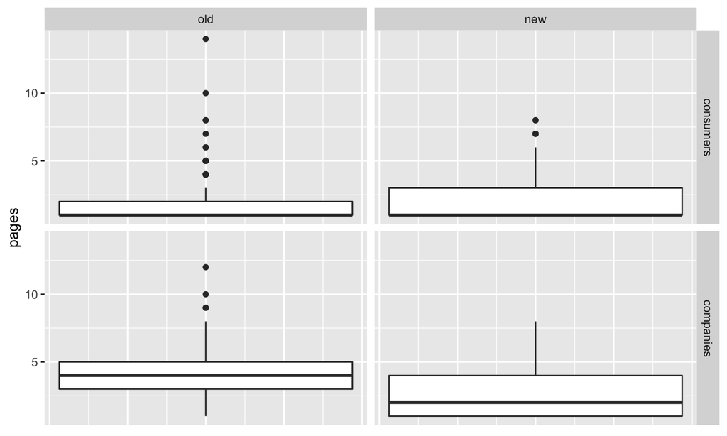

Boxplots of page visits on the website per independent variable.

### Normality check

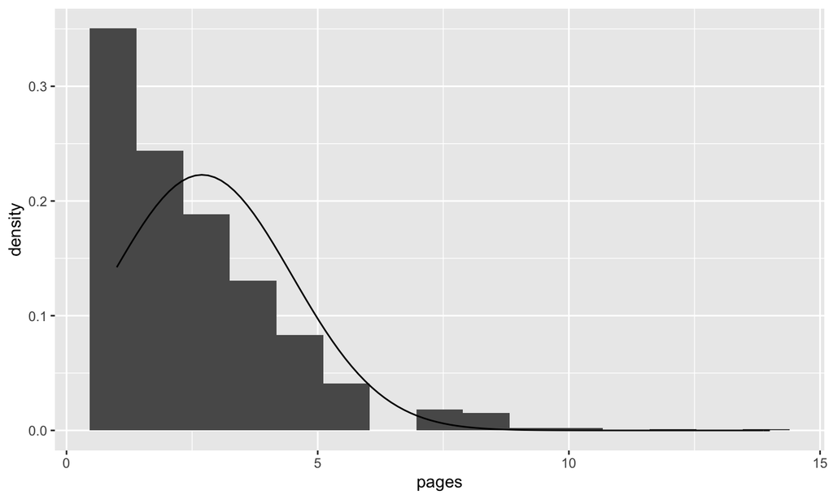

Normal distribution fitted to data of page visits

### Frequentist Approach

#### Model analysis - Levene’s Test

Levene’s Test to analyze the homogeniety of variance when adding the factors and the interaction between the factors.

Levene’s Test for Homogeneity of Variance (center = median)

|  | Df | F value | Pr(>F) |
| --- | --- | --- | --- |
| **group** | 3 | 2.562 | 0.05358 |
|  | 995 | NA | NA |

#### Model Analysis Results - 1

Website version as main effect on page visits

| Res.Df | RSS | Df | Sum of Sq | F | Pr(>F) |
| --- | --- | --- | --- | --- | --- |
| 998 | 3199 | NA | NA | NA | NA |
| 997 | 3107 | 1 | 92.2 | 29.59 | 6.731e-08 |

#### Model Analysis Results - 2

Portal type as main effect on page visits

| Res.Df | RSS | Df | Sum of Sq | F | Pr(>F) |
| --- | --- | --- | --- | --- | --- |
| 998 | 3199 | NA | NA | NA | NA |
| 997 | 2751 | 1 | 448.2 | 162.4 | 1.409e-34 |

#### Model Analysis Results - 3

Interation effect on top of two main effects

| Res.Df | RSS | Df | Sum of Sq | F | Pr(>F) |
| --- | --- | --- | --- | --- | --- |
| 996 | 2652 | NA | NA | NA | NA |
| 995 | 2534 | 1 | 117.8 | 46.25 | 1.793e-11 |

#### Model Analysis Results - 4

Effect of Website version, Portal type and interaction effect on page visits

|  | Df | Sum Sq | Mean Sq | F value | Pr(>F) |
| --- | --- | --- | --- | --- | --- |
| **version** | 1 | 92.2 | 92.2 | 36.2 | 2.495e-09 |
| **portal** | 1 | 455.3 | 455.3 | 178.8 | 1.283e-37 |
| **version:portal** | 1 | 117.8 | 117.8 | 46.25 | 1.793e-11 |
| **Residuals** | 995 | 2534 | 2.547 | NA | NA |

#### Model Analysis Results - 5

AIC comparison between models

|  | Modnames | K | AICc | Delta_AICc | ModelLik | AICcWt | LL | Cum.Wt |
| --- | --- | --- | --- | --- | --- | --- | --- | --- |
| **5** | model4 | 5 | 3775 | 0 | 1 | 1 | -1882 | 1 |
| **4** | model3 | 4 | 3818 | 43.37 | 3.824e-10 | 3.824e-10 | -1905 | 1 |
| **3** | model2 | 3 | 3853 | 78.07 | 1.117e-17 | 1.117e-17 | -1923 | 1 |
| **2** | model1 | 3 | 3975 | 199.6 | 4.451e-44 | 4.451e-44 | -1984 | 1 |
| **1** | model0 | 2 | 4002 | 226.8 | 5.517e-50 | 5.517e-50 | -1999 | 1 |

#### Simple Effect Analysis - Visual Inspection

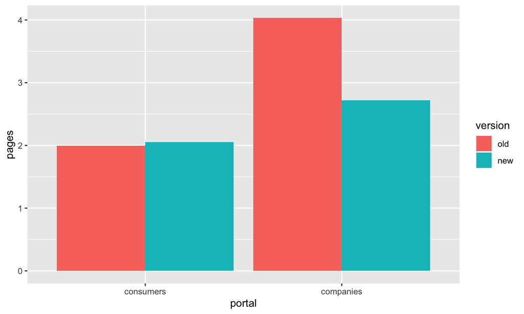

Bar plot showing the mean page visits per independent variable.

#### Simple Effect Analysis - Results

|  | Estimate | Std. Error | t value | Pr(>\|t\|) |
| --- | --- | --- | --- | --- |
| **(Intercept)** | 2.699 | 0.0505 | 53.45 | 9.614e-295 |
| **simplecontrastConsumers** | -0.03051 | 0.07166 | -0.4258 | 0.6703 |
| **simplecontrastCompanies** | 0.6563 | 0.07117 | 9.222 | 1.695e-19 |
| **simple** | 1.354 | 0.101 | 13.4 | 8.88e-38 |

Simple Effect Analysis of Portal on differences in page visits between website versions.

| Observations | Residual Std. Error | \(R^2\) | Adjusted \(R^2\) |
| --- | --- | --- | --- |
| 999 | 1.596 | 0.2079 | 0.2056 |

### Bayesian Approach

#### Model Description

\[ \begin{aligned} \text{PageVisits} & \sim N(\mu, \sigma) \\ \mu & = a + b \cdot \text{Version} + c \cdot \text{Portal} + d\cdot \text{Version} \cdot \text{Portal} \\ a & \sim \text{Gamma}(1, 2) \\ b & \sim N(0, 1) \\ c & \sim N(0, 1) \\ d & \sim N(0, 1) \\ \sigma & \sim U(0.1, 2) \end{aligned} \]

#### Gamma Distribution?

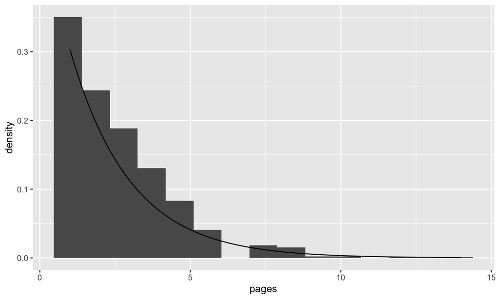

Gamma distribution (1, 2) fitted to data of page visits

#### Model Comparison

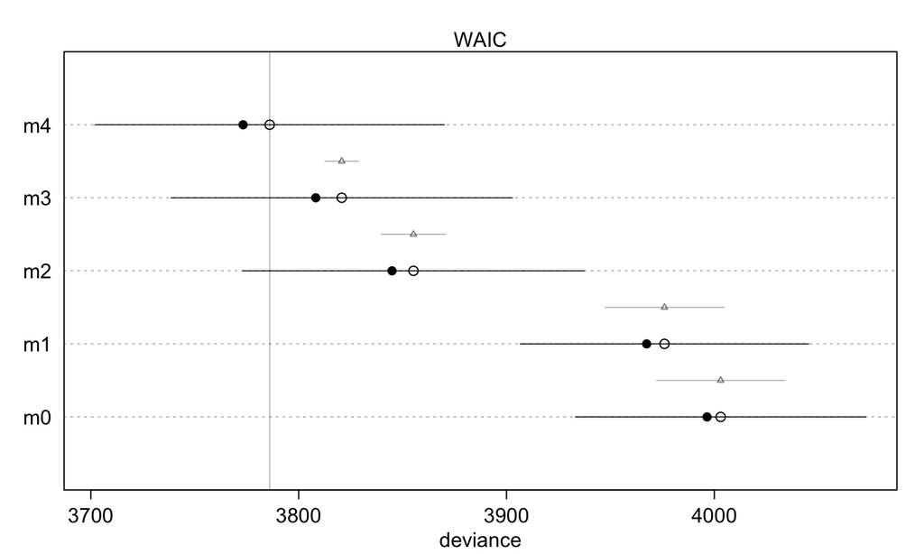

WAIC comparison between Bayesian models capturing effects of different variables.

#### Final Model

Coefficients of the fitted Bayesian model

|  | mean | sd | 2.5% | 97.5% | n_eff | Rhat4 |
| --- | --- | --- | --- | --- | --- | --- |
| **a** | 0.1543 | 0.1386 | 0.004448 | 0.5188 | 1346 | 1.003 |
| **b** | 0.4381 | 0.1289 | 0.1635 | 0.6713 | 1290 | 1.004 |
| **c** | 2.398 | 0.1301 | 2.12 | 2.638 | 1243 | 1.007 |
| **d** | -0.7561 | 0.09875 | -0.9466 | -0.5558 | 1031 | 1.007 |
| **sigma** | 1.606 | 0.03571 | 1.537 | 1.676 | 2592 | 1 |

## Part 3 - Multilevel model

## Visual inspection

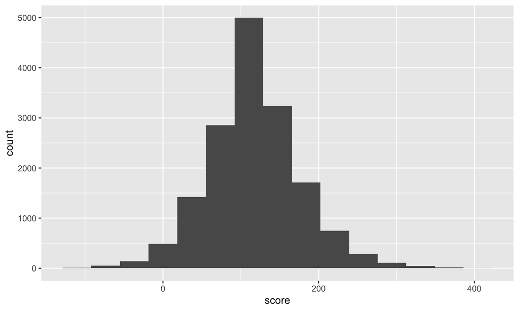

Histogram of score

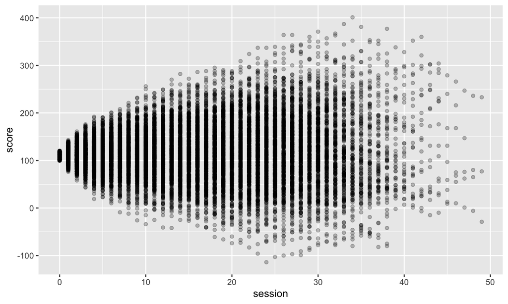

Scatterplot relation between score and session

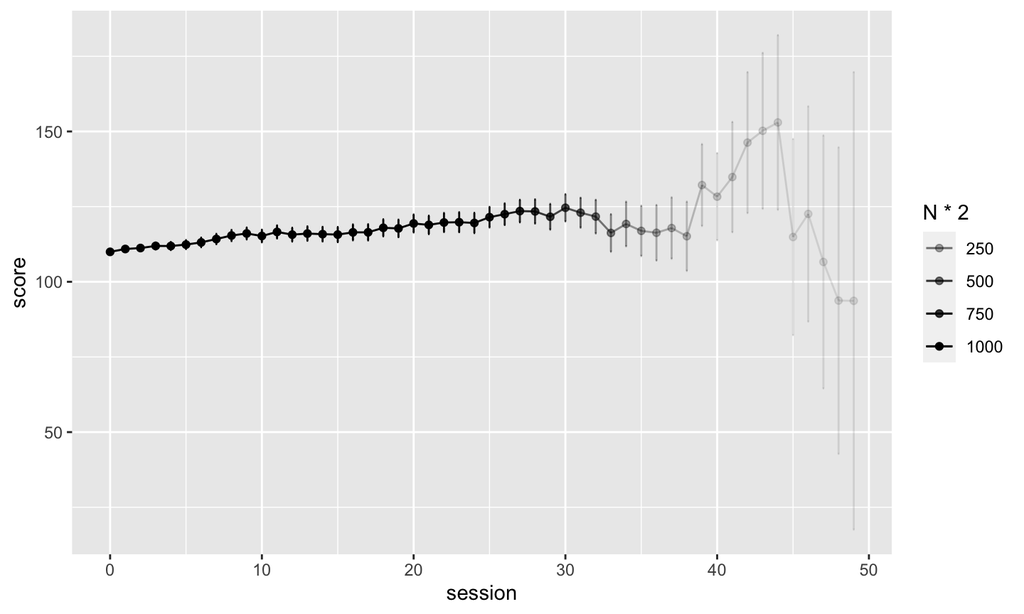

Mean score and standard error over sessions.

## Frequentist approach

### Multilevel analysis

```
## Linear mixed-effects model fit by maximum likelihood
##   Data: exp_data
##        AIC    BIC    logLik
##   162710.9 162734 -81352.45
##
## Random effects:
##  Formula: ~1 | Subject
##         (Intercept) Residual
## StdDev:    46.52747 35.25763
##
## Fixed effects:  score ~ 1
##                Value Std.Error    DF  t-value p-value
## (Intercept) 116.8139  2.097897 15627 55.68142       0
##
## Standardized Within-Group Residuals:
##         Min          Q1         Med          Q3         Max
## -4.22644590 -0.61530909  0.01016836  0.62959973  4.10477262
##
## Number of Observations: 16128
## Number of Groups: 501
```

```
## Approximate 95% confidence intervals
##
##  Fixed effects:
##                lower     est.    upper
## (Intercept) 112.7019 116.8139 120.9259
## attr(,"label")
## [1] "Fixed effects:"
##
##  Random Effects:
##   Level: Subject
##                    lower     est.    upper
## sd((Intercept)) 43.68633 46.52747 49.55338
##
##  Within-group standard error:
##    lower     est.    upper
## 34.86891 35.25763 35.65067
```

```
## Linear mixed-effects model fit by maximum likelihood
##   Data: exp_data
##        AIC      BIC    logLik
##   162545.2 162575.9 -81268.58
##
## Random effects:
##  Formula: ~1 | Subject
##         (Intercept) Residual
## StdDev:     46.5146 35.06933
##
## Fixed effects:  score ~ session
##                Value Std.Error    DF  t-value p-value
## (Intercept) 111.0676  2.143371 15626 51.81911       0
## session       0.3682  0.028356 15626 12.98493       0
##  Correlation:
##         (Intr)
## session -0.206
##
## Standardized Within-Group Residuals:
##          Min           Q1          Med           Q3          Max
## -4.120041920 -0.613554431  0.009847298  0.627208531  3.952634923
##
## Number of Observations: 16128
## Number of Groups: 501
```

```
## Approximate 95% confidence intervals
##
##  Fixed effects:
##                   lower        est.       upper
## (Intercept) 106.8665678 111.0675622 115.2685566
## session       0.3126229   0.3682005   0.4237781
## attr(,"label")
## [1] "Fixed effects:"
##
##  Random Effects:
##   Level: Subject
##                    lower    est.    upper
## sd((Intercept)) 43.67471 46.5146 49.53914
##
##  Within-group standard error:
##    lower     est.    upper
## 34.68269 35.06933 35.46028
```

Model comparison. (continued below)

|  | call | Model | df | AIC | BIC |
| --- | --- | --- | --- | --- | --- |
| **model0** | lme.formula(fixed = score ~ 1, data = exp_data, random = ~1 \| Subject, method = “ML”) | 1 | 3 | 162711 | 162734 |
| **model1** | lme.formula(fixed = score ~ session, data = exp_data, random = ~1 \| Subject, method = “ML”) | 2 | 4 | 162545 | 162576 |

|  | logLik | Test | L.Ratio | p-value |
| --- | --- | --- | --- | --- |
| **model0** | -81352 |  | NA | NA |
| **model1** | -81269 | 1 vs 2 | 167.7 | 2.317e-38 |

## Bayesian approach

### Model description

\[ \begin{aligned} \text{Score} & \sim N(\mu, \sigma) \\ \mu & = a + a_\text{Subject}[Subject] + b * \text{session} \\ a_\text{Subject}[Subject] & \sim N(0, \sigma_\text{Subject}) \\ \sigma_\text{Subject} & \sim \text{Cauchy}(0, 100)T(0, \infty) \\ a & \sim N(0, 100) \\ b & \sim N(0, 5) \\ \sigma & \sim \text{Cauchy}(0,50)T(0, \infty) \\ \end{aligned} \]

### Model comparison

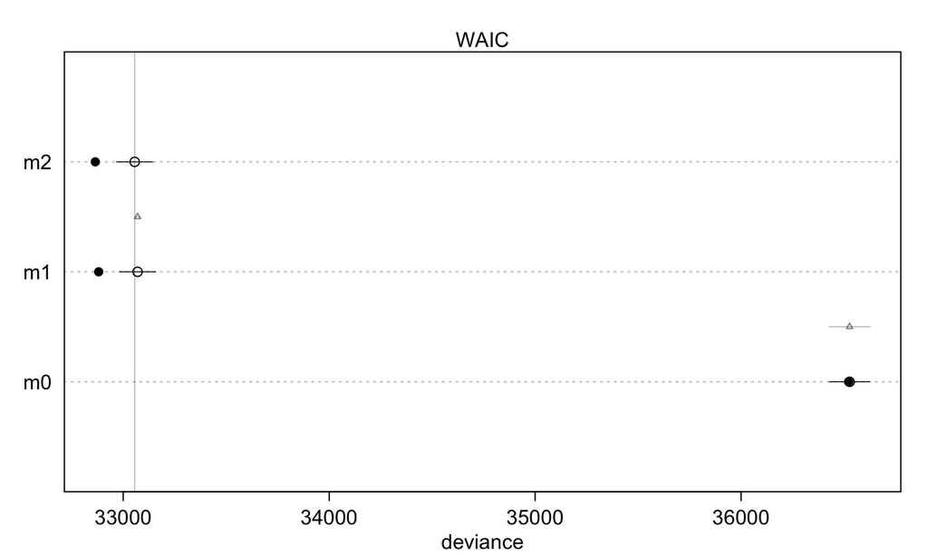

Comparing three Bayesian models of increasing complexity.

### Estimates examination

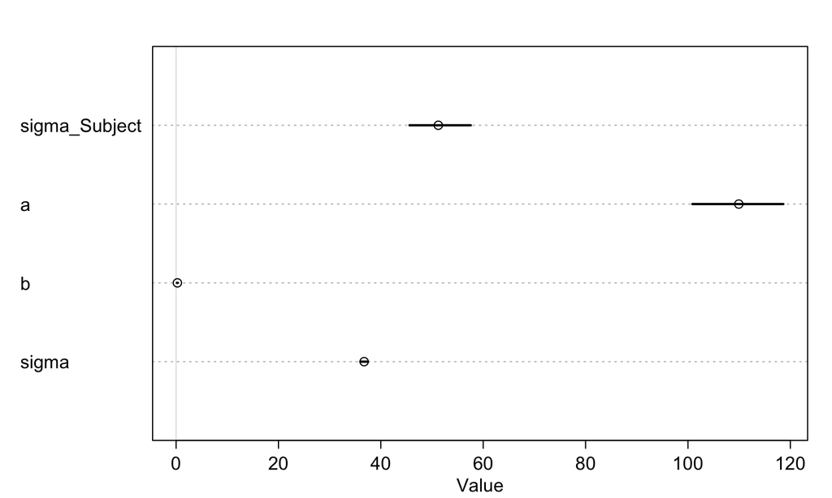

Parameters of m2.